# AIHA Abstract Analysis

# 1 Introduction

The following data exploration will produce descriptive statistics and explore the distribution of data in terms of duration of exposure for use of an AIHA abstract.

# 2 Data Exclusion

For the purposes of this analysis, we will begin by excluding observations taking place in 2026 so we can have full year data:

```r
study_dat |>
  filter(year == 2026) |>
  count()
```

```
##    n
## 1 92
```

```r
study_dat <- study_dat |>
  filter(year != 2026)
```

We excluded 92 observations.

# 3 General Data Summaries

How many observations?

```r
nrow(study_dat)
```

```
## [1] 2404
```

## 3.1 Study Period

I.E., what dates/years are covered by the time series data?

```r
range(study_dat$date_sampled)
```

```
## [1] "2004-02-23" "2025-12-30"
```

## 3.2 How many samples per year?

```r
study_dat |>
  group_by(year) |>
  summarize(n_year = n()) |>
  summarize(
    min_n = min(n_year),
    max_n = max(n_year)
  )
```

```
## # A tibble: 1 × 2
##   min_n max_n
##   <int> <int>
## 1     2   395
```

```r
study_dat |>
  group_by(year) |>
  summarize(n_year = n())
```

```
## # A tibble: 21 × 2
##    year  n_year
##    <fct>  <int>
##  1 2004       2
##  2 2006       5
##  3 2007      17
##  4 2008       5
##  5 2009      24
##  6 2010      62
##  7 2011     216
##  8 2012     176
##  9 2013     125
## 10 2014     125
## # ℹ 11 more rows
```

## 3.3 Duration

### 3.3.1 N by duration

```r
study_dat |>
  group_by(duration) |>
  count()
```

```
## # A tibble: 4 × 2
## # Groups:   duration [4]
##   duration        n
##   <chr>       <int>
## 1 Long-Term     993
## 2 Medium-Term  1166
## 3 Short-Term    219
## 4 Task-Based     26
```

### 3.3.2 Concentration by Duration

```r
study_dat |>
  group_by(duration) |>
  summarize(
    min_conc = min(silica_conc, na.rm = TRUE),
    max_conc = round(max(silica_conc, na.rm = TRUE),1),
    n_total  = n(),
    below_lod = sum(lod),
    pct_lod = round((100 * below_lod / n_total),1),
    over_AL  = sum(silica_conc > 25, na.rm = TRUE),
    over_PEL = sum(silica_conc > 50, na.rm = TRUE),
    pct_over_AL  = round((100 * over_AL / n_total),1),
    pct_over_PEL = round((100 * over_PEL / n_total),1)
  )
```

```
## # A tibble: 4 × 10
##   duration    min_conc max_conc n_total below_lod pct_lod over_AL over_PEL
##   <chr>          <dbl>    <dbl>   <int>     <int>   <dbl>   <int>    <int>
## 1 Long-Term          0    5093      993        33     3.3     436      291
## 2 Medium-Term        0    5711.    1166        34     2.9     581      417
## 3 Short-Term         0    6526.     219         5     2.3      73       71
## 4 Task-Based         0    7373.      26         2     7.7       9        9
## # ℹ 2 more variables: pct_over_AL <dbl>, pct_over_PEL <dbl>
```

## 3.4 LOD

How many observations were LOD? By duration?

```r
study_dat |>
  group_by(lod) |>
  count()
```

```
## # A tibble: 2 × 2
## # Groups:   lod [2]
##   lod       n
##   <lgl> <int>
## 1 FALSE  2330
## 2 TRUE     74
```

```r
#percentage
(74/2330)*100
```

```
## [1] 3.175966
```

```r
#by duration
study_dat |>
  group_by(duration,lod) |>
  count()
```

```
## # A tibble: 8 × 3
## # Groups:   duration, lod [8]
##   duration    lod       n
##   <chr>       <lgl> <int>
## 1 Long-Term   FALSE   960
## 2 Long-Term   TRUE     33
## 3 Medium-Term FALSE  1132
## 4 Medium-Term TRUE     34
## 5 Short-Term  FALSE   214
## 6 Short-Term  TRUE      5
## 7 Task-Based  FALSE    24
## 8 Task-Based  TRUE      2
```

## 3.5 Over PEL

Let’s start by summarizing in terms of by year:

```r
study_dat <- study_dat |>
  mutate(over_PEL = silica_conc >= 50)

over_PEL_annual <- study_dat |>
  group_by(year) |>
  summarize(annual_pct_over_pel = round(mean(over_PEL == "TRUE")*100, 2))

over_PEL_annual
```

```
## # A tibble: 21 × 2
##    year  annual_pct_over_pel
##    <fct>               <dbl>
##  1 2004                  0
##  2 2006                 20
##  3 2007                 29.4
##  4 2008                 20
##  5 2009                 25
##  6 2010                 38.7
##  7 2011                 30.1
##  8 2012                 34.7
##  9 2013                 30.4
## 10 2014                 30.4
## # ℹ 11 more rows
```

Next, let’s summarize in terms of duration category:

```r
over_PEL_duration <- study_dat |>
  group_by(duration) |>
  summarize(annual_pct_over_pel = round(mean(over_PEL == "TRUE")*100, 2))

over_PEL_duration
```

```
## # A tibble: 4 × 2
##   duration    annual_pct_over_pel
##   <chr>                     <dbl>
## 1 Long-Term                  29.4
## 2 Medium-Term                35.8
## 3 Short-Term                 32.4
## 4 Task-Based                 34.6
```

# 4 Plots

## 4.1 AL and PEL plot

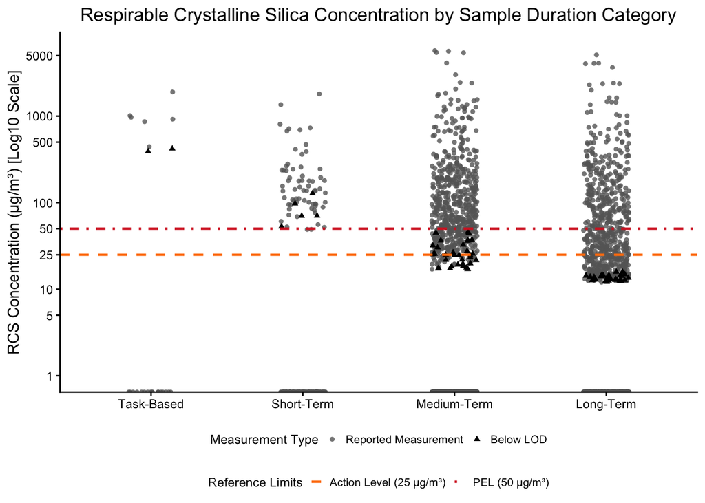

```r
# --- Prep: order duration groups, label lod status ---
plot_dat <- study_dat %>%
  mutate(
    duration = factor(duration,
                         levels = c("Task-Based", "Short-Term", "Medium-Term", "Long-Term")),
    lod_status = factor(lod, levels = c(FALSE, TRUE),
                         labels = c("Reported Measurement", "Below LOD"))
  )

ggplot(plot_dat, aes(x = duration, y = silica_conc, shape = lod_status, color = lod_status)) +

  # Reported Measurement: drawn first (bottom layer), semi-transparent
  geom_jitter(
    data = subset(plot_dat, lod_status == "Reported Measurement"),
    width = 0.15, size = 1.3, alpha = 0.8
  ) +

  # Below LOD: drawn second (top layer), fully opaque, no alpha
  geom_jitter(
    data = subset(plot_dat, lod_status == "Below LOD"),
    width = 0.15, size = 1.3, alpha = 1
  ) +

  # Reference limits (fixed colors via override so they don't clash with the point color scale)
  geom_hline(aes(yintercept = 25, linetype = "Action Level (25 µg/m³)"),
             color = "#ff7f0e", linewidth = 0.8) +
  geom_hline(aes(yintercept = 50, linetype = "PEL (50 µg/m³)"),
             color = "#d62728", linewidth = 0.8) +
  scale_y_log10(
    breaks = c(1, 5, 10, 25, 50, 100, 500, 1000, 5000),
    limits = c(1, 6000)
  ) +
  scale_shape_manual(
    name = "Measurement Type",
    values = c("Reported Measurement" = 16,
               "Below LOD" = 17)
  ) +
  scale_color_manual(
    name = "Measurement Type",
    values = c("Reported Measurement" = "grey40",
               "Below LOD" = "black")
  ) +
  scale_linetype_manual(
    name = "Reference Limits",
    values = c("Action Level (25 µg/m³)" = "dashed",
               "PEL (50 µg/m³)" = "dotdash")
  ) +
  guides(
    linetype = guide_legend(override.aes = list(colour = c("#ff7f0e", "#d62728")))
  ) +
  labs(
    title = "Respirable Crystalline Silica Concentration by Sample Duration Category",
    x = NULL,
    y = "RCS Concentration (µg/m³) [Log10 Scale]"
  ) +
  theme_classic() +
  theme(
    plot.title = element_text(hjust = 0.5),
    legend.position = "bottom",
    legend.box = "vertical",
    legend.key.size = unit(0.3, "cm"),
     legend.text = element_text(size = 8),
    legend.title = element_text(size = 9)
  )
```

## 4.2 Over PEL Plot:

```r
study_dat <- study_dat |>
  mutate(over_PEL = silica_conc > 50)

over_PEL <- study_dat |>
  group_by(year) |>
  summarize(annual_pct_over_pel = round(mean(over_PEL == "TRUE")*100, 2))

over_PEL
```

```
## # A tibble: 21 × 2
##    year  annual_pct_over_pel
##    <fct>               <dbl>
##  1 2004                  0
##  2 2006                 20
##  3 2007                 29.4
##  4 2008                 20
##  5 2009                 25
##  6 2010                 38.7
##  7 2011                 30.1
##  8 2012                 34.7
##  9 2013                 30.4
## 10 2014                 30.4
## # ℹ 11 more rows
```

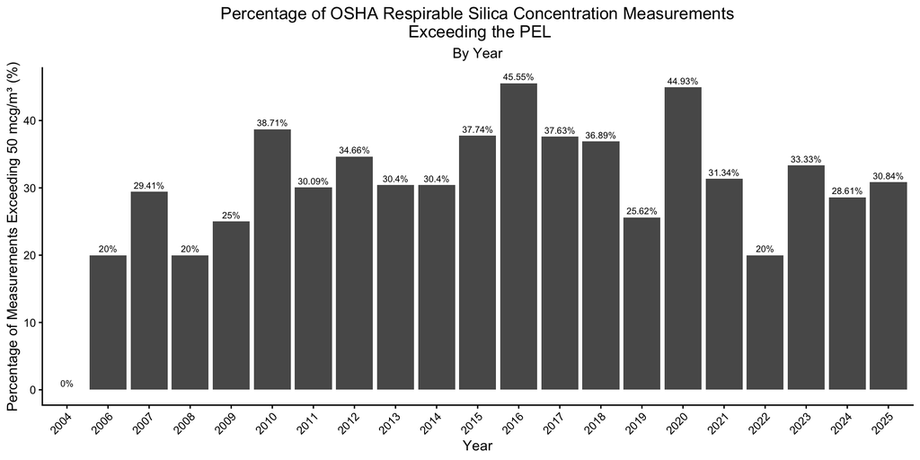

```r
ggplot(over_PEL, aes(year, annual_pct_over_pel))+
  geom_col()+
  labs(x = "Year", y = "Percentage of Measurements Exceeding 50 mcg/m³ (%)")+
  ggtitle("Percentage of OSHA Respirable Silica Concentration Measurements\n Exceeding the PEL", subtitle = "By Year" )+

 geom_text(aes(label = paste0(annual_pct_over_pel, "%"), vjust = -0.5), size = 2.5)+

   theme_classic()+

  theme(plot.title = element_text(hjust = 0.5),
    plot.subtitle = element_text(hjust = 0.5),
    axis.text.x = element_text(angle = 45, hjust = 1))
```

What about Over PEL by Duration??

```r
over_PEL_duration <- study_dat |>
  group_by(year,duration) |>
  summarize(annual_pct_over_pel = round(mean(over_PEL == "TRUE")*100, 2))

over_PEL_duration
```

```
## # A tibble: 73 × 3
## # Groups:   year [21]
##    year  duration    annual_pct_over_pel
##    <fct> <chr>                     <dbl>
##  1 2004  Long-Term                   0
##  2 2006  Long-Term                   0
##  3 2006  Medium-Term                50
##  4 2006  Short-Term                  0
##  5 2007  Long-Term                  16.7
##  6 2007  Medium-Term                80
##  7 2007  Short-Term                  0
##  8 2008  Medium-Term                20
##  9 2009  Long-Term                  33.3
## 10 2009  Medium-Term                31.2
## # ℹ 63 more rows
```

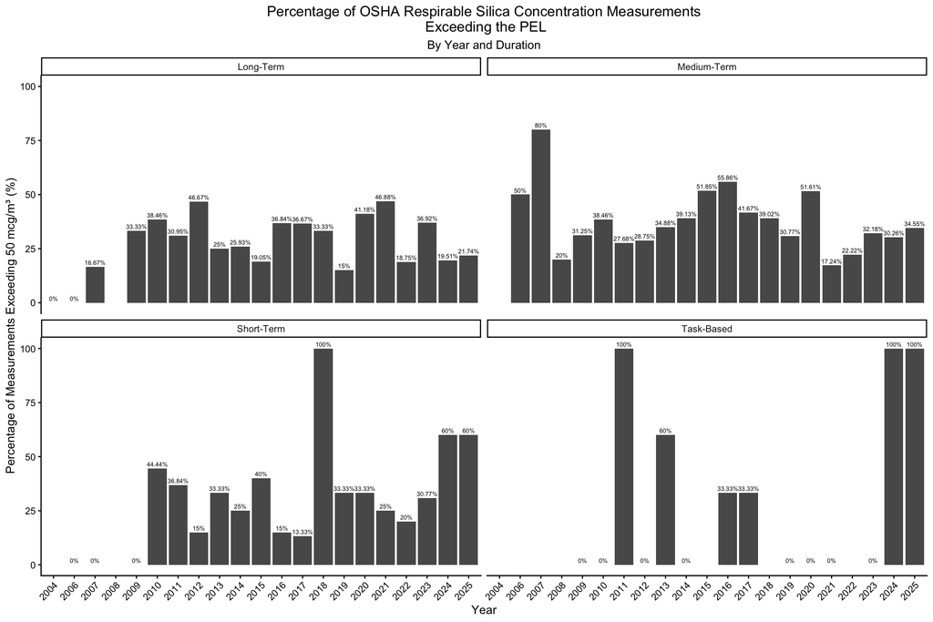

```r
ggplot(over_PEL_duration, aes(year, annual_pct_over_pel))+
  facet_wrap(~duration)+
  geom_col()+
  labs(x = "Year", y = "Percentage of Measurements Exceeding 50 mcg/m³ (%)")+
  ggtitle("Percentage of OSHA Respirable Silica Concentration Measurements\n Exceeding the PEL", subtitle = "By Year and Duration" )+

 geom_text(aes(label = paste0(annual_pct_over_pel, "%"), vjust = -0.5), size = 2)+

   theme_classic()+

  theme(plot.title = element_text(hjust = 0.5),
    plot.subtitle = element_text(hjust = 0.5),
    axis.text.x = element_text(angle = 45, hjust = 1))
```

# 5 Temporal Trends

## 5.1 Median concentration reported per year

The OSHA citations database was used to analyze the median concentration reported per year. We can replicate the same analysis:

Do we have all of the years covered by this data?

```r
study_dat |>
  select(year) |>
  unique()
```

```
##      year
## 1    2025
## 215  2024
## 610  2023
## 778  2022
## 858  2021
## 925  2020
## 994  2019
## 1115 2018
## 1168 2017
## 1404 2016
## 1595 2015
## 1648 2014
## 1773 2013
## 1898 2012
## 2074 2011
## 2290 2010
## 2352 2009
## 2376 2008
## 2381 2007
## 2398 2006
## 2403 2004
```

We are missing data for the year 2005. We will also have to do the year counter process.

## 5.2 Year Counter Creaqtion

```r
dat_clean <- study_dat |>
  mutate(year = as.numeric(as.character(year))) |>
  arrange(year) |>
  mutate(year_counter = dense_rank(year) - 1)

dat_clean |>
  distinct(year, year_counter) |>
  arrange(year)
```

```
##    year year_counter
## 1  2004            0
## 2  2006            1
## 3  2007            2
## 4  2008            3
## 5  2009            4
## 6  2010            5
## 7  2011            6
## 8  2012            7
## 9  2013            8
## 10 2014            9
## 11 2015           10
## 12 2016           11
## 13 2017           12
## 14 2018           13
## 15 2019           14
## 16 2020           15
## 17 2021           16
## 18 2022           17
## 19 2023           18
## 20 2024           19
## 21 2025           20
```

## 5.3 Crude mod:

Get the median by year first, then fit linear trend.

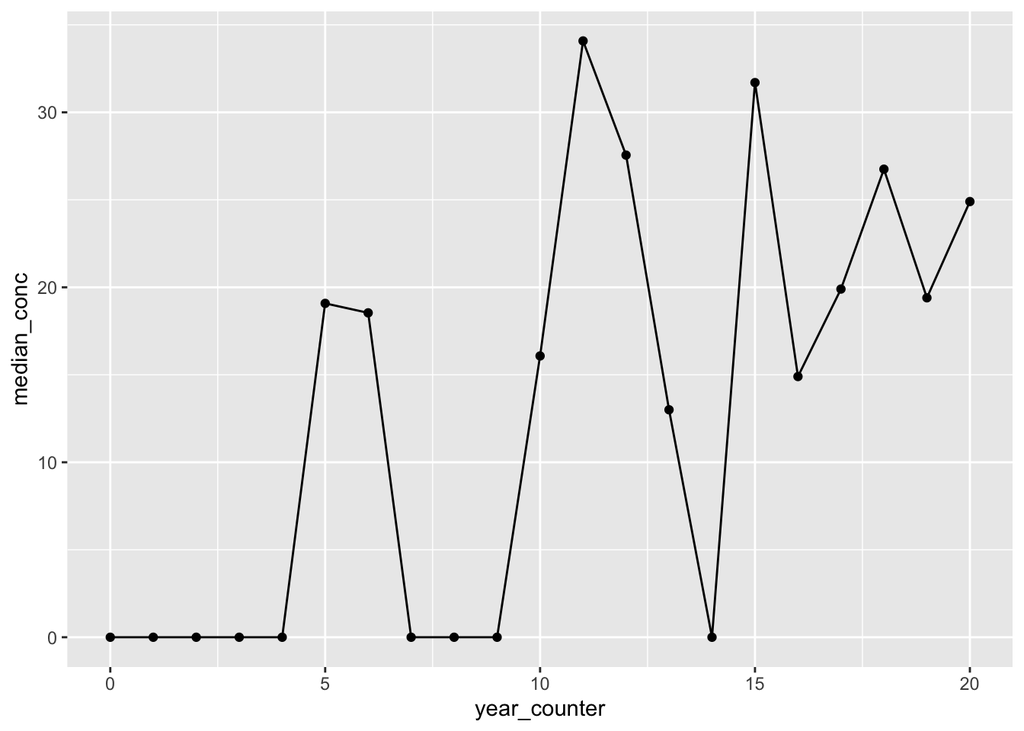

```r
median_by_year <- dat_clean |>
  group_by(year_counter) |>
  summarize(median_conc = median(silica_conc, na.rm = TRUE))

ggplot(data=median_by_year,aes(year_counter,median_conc))+
  geom_point()+
  geom_line()
```

```r
mod_median_trend <- lm(median_conc ~ year_counter, data = median_by_year)
summary(mod_median_trend)
```

```
##
## Call:
## lm(formula = median_conc ~ year_counter, data = median_by_year)
##
## Residuals:
##     Min      1Q  Median      3Q     Max
## -17.770  -4.998  -1.701   3.872  20.142
##
## Coefficients:
##              Estimate Std. Error t value Pr(>|t|)
## (Intercept)   -0.1106     4.0645  -0.027  0.97857
## year_counter   1.2772     0.3477   3.673  0.00161 **
## ---
## Signif. codes:  0 '***' 0.001 '**' 0.01 '*' 0.05 '.' 0.1 ' ' 1
##
## Residual standard error: 9.648 on 19 degrees of freedom
## Multiple R-squared:  0.4153, Adjusted R-squared:  0.3845
## F-statistic: 13.49 on 1 and 19 DF,  p-value: 0.001615
```

There is a statistically significant relationship here whereby the median concentration increases by 1.3 units for each additional year in the study period.

## 5.4 Median by Duration

Get the median by year and duration:

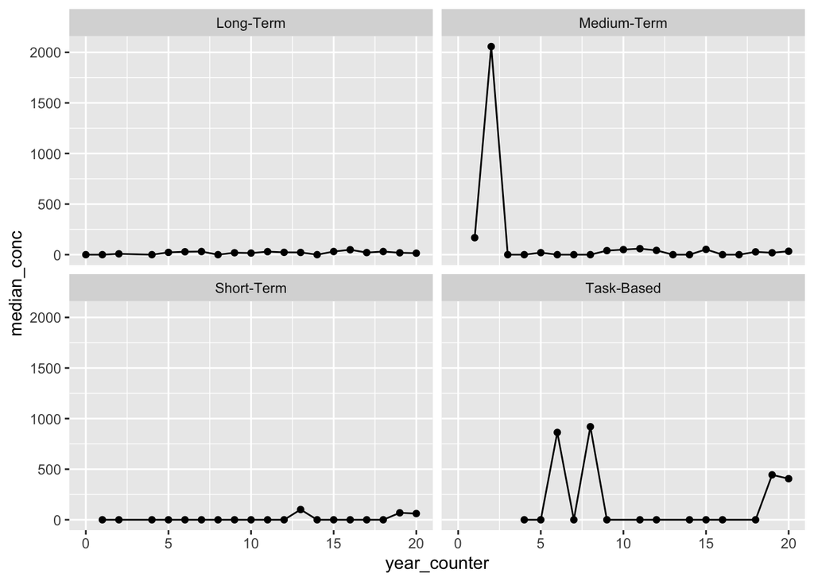

```r
median_by_year_and_duration <- dat_clean |>
  group_by(year_counter,duration) |>
  summarize(median_conc = median(silica_conc, na.rm = TRUE))

ggplot(data=median_by_year_and_duration,aes(year_counter,median_conc))+
  facet_wrap(~duration)+
  geom_point()+
  geom_line()
```

```r
mod_median_trend2 <- lm(median_conc ~ year_counter*duration, data = median_by_year_and_duration)
summary(mod_median_trend2)
```

```
##
## Call:
## lm(formula = median_conc ~ year_counter * duration, data = median_by_year_and_duration)
##
## Residuals:
##     Min      1Q  Median      3Q     Max
## -334.42  -91.98   -8.39   10.19 1695.20
##
## Coefficients:
##                                  Estimate Std. Error t value Pr(>|t|)
## (Intercept)                         7.325    122.615   0.060   0.9525
## year_counter                        1.066     10.252   0.104   0.9175
## durationMedium-Term               409.449    177.004   2.313   0.0239 *
## durationShort-Term                -19.070    183.864  -0.104   0.9177
## durationTask-Based                235.165    218.923   1.074   0.2867
## year_counter:durationMedium-Term  -28.518     14.787  -1.929   0.0582 .
## year_counter:durationShort-Term     1.130     15.158   0.075   0.9408
## year_counter:durationTask-Based    -5.712     17.478  -0.327   0.7449
## ---
## Signif. codes:  0 '***' 0.001 '**' 0.01 '*' 0.05 '.' 0.1 ' ' 1
##
## Residual standard error: 274.8 on 65 degrees of freedom
## Multiple R-squared:  0.153,  Adjusted R-squared:  0.06183
## F-statistic: 1.678 on 7 and 65 DF,  p-value: 0.1301
```

There is no significant trend when we differentiate by duration.

# 6 All measurements

## 6.1 Linear Model

Let’s try our glm again, this time with the pure silica conc instead of median concentration:

```r
mod_linear_reg <- glm(silica_conc ~ year_counter, data = dat_clean)
summary(mod_linear_reg)
```

```
##
## Call:
## glm(formula = silica_conc ~ year_counter, data = dat_clean)
##
## Coefficients:
##              Estimate Std. Error t value Pr(>|t|)
## (Intercept)   191.854     24.204   7.926 3.42e-15 ***
## year_counter   -5.427      1.729  -3.140  0.00171 **
## ---
## Signif. codes:  0 '***' 0.001 '**' 0.01 '*' 0.05 '.' 0.1 ' ' 1
##
## (Dispersion parameter for gaussian family taken to be 191794.4)
##
##     Null deviance: 462580761  on 2403  degrees of freedom
## Residual deviance: 460690202  on 2402  degrees of freedom
## AIC: 36069
##
## Number of Fisher Scoring iterations: 2
```

```r
extract_eq(mod_linear_reg)
```

$$E( \operatorname{silica_conc} ) = \alpha +
\beta_{1}(\operatorname{year\_counter})$$

Let’s control for our within-establishment variation:

```r
coeftest(mod_linear_reg,
         vcov = vcovCL(mod_linear_reg,
                       cluster = ~ establishment,
                       type = "HC1"))
```

```
##
## z test of coefficients:
##
##              Estimate Std. Error z value  Pr(>|z|)
## (Intercept)  191.8544    43.7050  4.3898 1.135e-05 ***
## year_counter  -5.4273     2.8677 -1.8926   0.05842 .
## ---
## Signif. codes:  0 '***' 0.001 '**' 0.01 '*' 0.05 '.' 0.1 ' ' 1
```

### 6.1.1 By Duration

This time, let’s see whether duration interacts with this relationship:

```r
mod_linear_reg2 <- glm(silica_conc ~ year_counter * duration, data = dat_clean)
summary(mod_linear_reg2)
```

```
##
## Call:
## glm(formula = silica_conc ~ year_counter * duration, data = dat_clean)
##
## Coefficients:
##                                  Estimate Std. Error t value Pr(>|t|)
## (Intercept)                      100.8969    37.8955   2.663 0.007808 **
## year_counter                       0.6515     2.6800   0.243 0.807941
## durationMedium-Term              160.1214    51.5510   3.106 0.001918 **
## durationShort-Term                40.6574    81.6040   0.498 0.618370
## durationTask-Based               841.7217   234.6392   3.587 0.000341 ***
## year_counter:durationMedium-Term -11.0375     3.6515  -3.023 0.002531 **
## year_counter:durationShort-Term   -3.7424     6.1827  -0.605 0.545041
## year_counter:durationTask-Based  -33.1787    18.0247  -1.841 0.065785 .
## ---
## Signif. codes:  0 '***' 0.001 '**' 0.01 '*' 0.05 '.' 0.1 ' ' 1
##
## (Dispersion parameter for gaussian family taken to be 189305.5)
##
##     Null deviance: 462580761  on 2403  degrees of freedom
## Residual deviance: 453576095  on 2396  degrees of freedom
## AIC: 36044
##
## Number of Fisher Scoring iterations: 2
```

```r
extract_eq(mod_linear_reg2)
```

Let’s plot what the model is showing us:

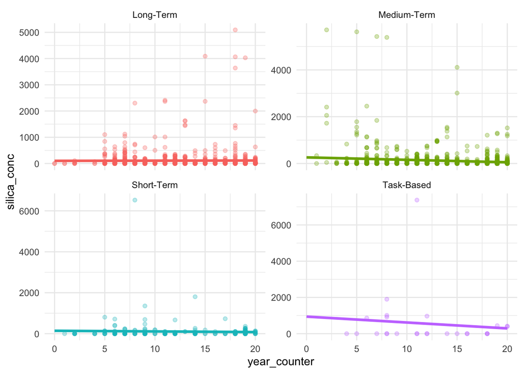

```r
# Generate predictions from the model across the range of year_counter for each duration
pred_grid <- dat_clean |>
  distinct(duration) |>
  tidyr::crossing(year_counter = seq(min(dat_clean$year_counter, na.rm = TRUE),
                                       max(dat_clean$year_counter, na.rm = TRUE),
                                       length.out = 100))

pred_grid$predicted <- predict(mod_linear_reg2 , newdata = pred_grid)

ggplot() +
  geom_point(data = dat_clean, aes(x = year_counter, y = silica_conc, color = duration), alpha = 0.3) +
  geom_line(data = pred_grid, aes(x = year_counter, y = predicted, color = duration), linewidth = 1.2) +
  facet_wrap(~ duration, scales = "free_y") +
  theme_minimal() +
  theme(legend.position = "none")
```

### 6.1.2 Over PEL

What if we instead investigate a logistic model that investigates whether the number of facilities exceeding the PEL has changed over the years?

```r
mod_logistic  <- glm(over_PEL~year_counter, data = dat_clean,
                     family = binomial)
summary(mod_logistic)
```

```
##
## Call:
## glm(formula = over_PEL ~ year_counter, family = binomial, data = dat_clean)
##
## Coefficients:
##               Estimate Std. Error z value Pr(>|z|)
## (Intercept)  -0.570945   0.116877  -4.885 1.03e-06 ***
## year_counter -0.011362   0.008404  -1.352    0.176
## ---
## Signif. codes:  0 '***' 0.001 '**' 0.01 '*' 0.05 '.' 0.1 ' ' 1
##
## (Dispersion parameter for binomial family taken to be 1)
##
##     Null deviance: 3041.5  on 2403  degrees of freedom
## Residual deviance: 3039.7  on 2402  degrees of freedom
## AIC: 3043.7
##
## Number of Fisher Scoring iterations: 4
```

```r
extract_eq(mod_logistic)
```

$$\log\left[ \frac { P( \operatorname{over\_PEL} = \operatorname{TRUE} )
}{ 1 - P( \operatorname{over\_PEL} = \operatorname{TRUE} ) } \right] =
\alpha + \beta_{1}(\operatorname{year\_counter})$$

No significant relationship here.

```r
coeftest(mod_logistic,
         vcov = vcovCL(mod_logistic,
                       cluster = ~ establishment,
                       type = "HC1"))
```

```
##
## z test of coefficients:
##
##               Estimate Std. Error z value Pr(>|z|)
## (Intercept)  -0.570945   0.202086 -2.8252 0.004724 **
## year_counter -0.011362   0.015072 -0.7538 0.450948
## ---
## Signif. codes:  0 '***' 0.001 '**' 0.01 '*' 0.05 '.' 0.1 ' ' 1
```

# 7 Do Establishments improve over time?

We want to check out the establishments that have multiple observations, and investigate whether they improve over time:

Some establishments have multiple samples on the same day, so we will take the median conc only for those instances:

```r
est_daily <- study_dat |>
  group_by(establishment, date_sampled) |>
  summarize(median_conc = median(silica_conc, na.rm = TRUE), .groups = "drop")
```

Next we only keep establishments with multiple distinct sampling dates:

```r
est_multi <- est_daily |>
  group_by(establishment) |> #just looking at establishment
  filter(n() >= 2) |> #only those that have multiple measurements
  arrange(establishment, date_sampled)#in order of date sampled
```

Let’s figure out the change between consecutive measurements:

```r
est_changes <- est_multi |>
  group_by(establishment) |>
  mutate(
    conc_change = median_conc - lag(median_conc), #median conc measurement MINUS the previous one
    days_elapsed = as.numeric(date_sampled - lag(date_sampled)), #number of days between consecuitve measurements
    years_elapsed = days_elapsed / 365.25, #converting days into years
    rate_per_year = conc_change / years_elapsed #the change in establishments divided by time elaspsed
  ) |>
  filter(!is.na(conc_change))  #removing rows where conc_change is NA (each establishment's first row -- only retaining a measured change between two timepoints)
```

```r
est_changes
```

```
## # A tibble: 157 × 7
## # Groups:   establishment [118]
##    establishment date_sampled median_conc conc_change days_elapsed years_elapsed
##    <chr>         <date>             <dbl>       <dbl>        <dbl>         <dbl>
##  1 ABSOLUTE SUR… 2017-04-27          33.6      -160.            87       0.238
##  2 ADAMS MONUME… 2016-03-18           0           0             49       0.134
##  3 ADAMS MONUME… 2016-03-21           0           0              3       0.00821
##  4 AFFORDABLE G… 2024-01-11          16          -3              7       0.0192
##  5 AJ MARBLE AN… 2024-02-26           0           0             34       0.0931
##  6 ALISE MARBLE… 2024-01-16           0         -61.2           31       0.0849
##  7 ALL GRANITE … 2023-11-29          20.4        20.4         1997       5.47
##  8 ALL GRANITE … 2012-04-26         125.        -21.7          205       0.561
##  9 ALL GRANITE … 2012-11-15           0        -125.           203       0.556
## 10 ALL GRANITE … 2019-01-17           0           0           2254       6.17
## # ℹ 147 more rows
## # ℹ 1 more variable: rate_per_year <dbl>
```

```r
est_changes |>
  ungroup() |>
  summarize(
    mean_rate = mean(rate_per_year, na.rm = TRUE),
    median_rate = median(rate_per_year, na.rm = TRUE)
  )
```

```
## # A tibble: 1 × 2
##   mean_rate median_rate
##       <dbl>       <dbl>
## 1    -2598.           0
```

```r
#NOTE: this includes changes between the same establishment at different time points (i.e., if an establishment was measured 3 times, it will contribute 2 changes below)
est_changes |>
  ungroup() |>
  mutate(direction = case_when(
    conc_change < 0 ~ "improved",
    conc_change > 0 ~ "worsened",
    TRUE ~ "unchanged"
  )) |>
  count(direction) |>
  mutate(pct = 100 * n / sum(n))
```

```
## # A tibble: 3 × 3
##   direction     n   pct
##   <chr>     <int> <dbl>
## 1 improved     75  47.8
## 2 unchanged    29  18.5
## 3 worsened     53  33.8
```

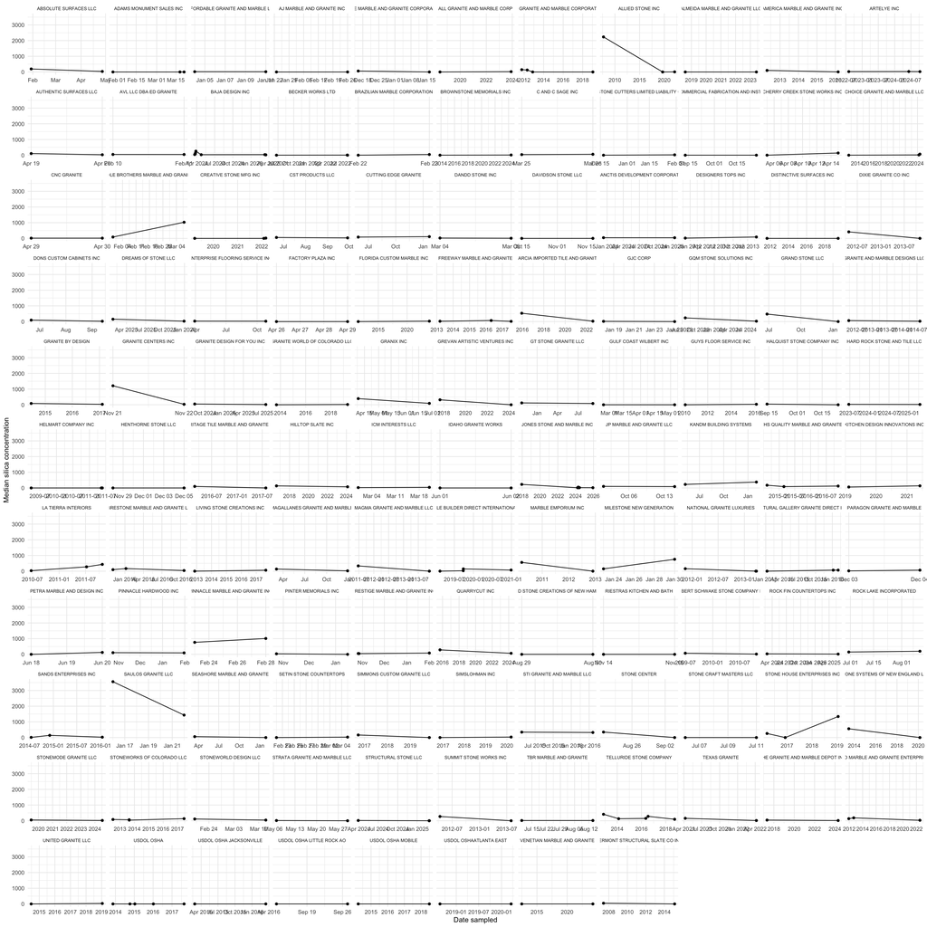

```r
ggplot(est_multi, aes(x = date_sampled, y = median_conc)) +
  geom_line() +
  geom_point() +
  facet_wrap(~ establishment, scales = "free_x") +
  labs(x = "Date sampled", y = "Median silica concentration") +
  theme_minimal() +
  theme(strip.text = element_text(size = 7))
```